# Basic Intro to R

## The Interactive Interpreter

Open R and type `2 + 2`. R tells you that the answer is `4`.

Congrats! You are now using R.

This is the most basic way to interact with the interpreter.

Later we will see how you can save a complicated series of commands to a script file and execute them automatically.

## Assignment

Sometimes it is useful to assign the results of computations to a named variable that we will use later.

We can create a named variable using the `<-` assignment operator.

**Note** It is technically possible to use the `=` symbol for assignment, but this is bad form. Get used to typing the `<-` symbol.

```r
myVariable <- 2 + 2
```

Now the result from this computation is assigned to `myVariable` and saved for later use. Later, we can call this variable like so:

```r
myVariable * myVariable
```

```
## [1] 16
```

## Atomic vectors

An atomic vector is a series of values stored in a single object.

You can create a vector using the `c()` function (**c** stands for **combine**).

**Note**: you can only store a single type of data in a vector (e.g. numeric or character data).

```r
vector1 <- c(1,2,3,4,5,6,7,8,9,10)
vector2 <- c(11,12,13,14,15,16,17,18,19,20)
```

## Atomic vectors

Many of the basic functions and operations in R are **vectorized**, meaning that they operate on all elements of a vector in sequence.

For example, to add the elements of `vector1` with the corresponding elements in `vector2`, you simply add the vectors, because the `+` function is vectorized.

This is one of the fundamental advantages of R.

```r
vector1 + vector2
```

```
##  [1] 12 14 16 18 20 22 24 26 28 30
```

## Atomic vectors

What happens when I try this?

```
vector3 <- c(21,22,23,24,25,26,27,28,29,"thirty")
```

What type of vector is `vector3`?

What happens when I do this? `vector2 + vector3`

## Accessing values within a vector

Vectors can be **indexed** with brackets `[]` to get a subset of values.

What value do you get by typing `vector2[3]` in the interpreter?

What about `vector2[3:5]`? HINT: the `:` operator makes a sequence of integers.

## Challenge

Extract the first, fifth, and ninth element of `vector2` that you created earlier.

## Negative Indexing

When you use negative indices, then the referenced elements are **removed** from the resulting vector.

```r
dwarves <- c("Dopey", "Gimli", "Larry")
dwarves[-3] #real dwarves
```

```
## [1] "Dopey" "Gimli"
```

**Note**: comments using the octothorpe (AKA the hashtag #) are for people

## Challenge

Remove the 1st, 5th and 9th elements from `vector2`

## Logical Tests

Logical tests are assertions that R evaluates as either `TRUE` or `FALSE`.

For instance, you might assert that "1 plus 1 equals 10 minus 8"?

In R that looks like:

```r
1 + 1 == 10 - 8
```

```
## [1] TRUE
```

R tells us that this is `TRUE`.

Note the double equals symbol, which means something different than a single equals symbol.

## Logical operators

The logical operators are:

- `==` is equal to
- `!=` does not equal
- `>` greater than
- `<` less than
- `>=` greater than or equal to
- `<=` less than or equal to

## Logical indexing

Like most things in R, logical tests work on vectors.

Remember `vector2` from before?

```r
vector2
```

```
##  [1] 11 12 13 14 15 16 17 18 19 20
```

Lets find out which values are greater than 17.

```r
vector2 > 17
```

```
##  [1] FALSE FALSE FALSE FALSE FALSE FALSE FALSE  TRUE  TRUE  TRUE
```

## Logical indexing

This becomes useful when you only want a subset of values from a vector using logical indexing.

To get **only** the values of `vector2` that are greater than 17, we can use a logical (AKA boolean) vector.

```r
vector2[vector2 > 17]
```

```
## [1] 18 19 20
```

You can also pass complicated logical tests using the AND operator `&` or the logical OR operator `|`

```r
vector2[vector2 > 17 & vector2 < 20]
```

```
## [1] 18 19
```

```r
vector2[vector2 > 17 | vector2 == 13]
```

```
## [1] 13 18 19 20
```

## Assignment & Indexing

You can also use `<-` to replace particular elements in a vector.

```r
primates <- c("gorilla", "gibbon", "langur", "gibbon", "gorilla")
primates
```

```
## [1] "gorilla" "gibbon"  "langur"  "gibbon"  "gorilla"
```

```r
primates[3] <- "bushbaby"
primates
```

```
## [1] "gorilla"  "gibbon"   "bushbaby" "gibbon"   "gorilla"
```

```r
primates[primates == "gorilla"] <- "chimpanzee"
primates
```

```
## [1] "chimpanzee" "gibbon"     "bushbaby"   "gibbon"     "chimpanzee"
```

## Factors

A factor is a special type of vector for storing categorical data.

```r
pets <- factor(c("cat", "cat", "dog", "pony", "dog", "dog"))
pets
```

```
## [1] cat  cat  dog  pony dog  dog
## Levels: cat dog pony
```

R will now treat this differently from other vectors.

These come in useful later on, when we want to summarize by different factor levels.

## Ordered factors

By default, R assumes the order of the levels in your factor is alphabetical.

You can change this by replacing the normal factor `pets` with a new *ordered* factor

```r
pets <- ordered(pets, levels=c("pony", "dog", "cat"))
pets
```

```
## [1] cat  cat  dog  pony dog  dog
## Levels: pony < dog < cat
```

## Data Frames

Data frames store related vectors of data together in a single object.

They are analogous to a spreadsheet:

- each row corresponds to an individual (e.g., specimen, species)
- each column corresponds to some observation about that individual

You will use the `read.table()` function to read a dataframe directly from a .csv or .txt file

## Accessing data in a dataframe

`$` is used to access a named column within an dataframe

The `[row, column]` syntax is used to identify the index number of the row and column desired

## Accessing data in a dataframe

Lets extract particular data within the built-in dataframe `iris`

```r
head(iris)
```

```
##   Sepal.Length Sepal.Width Petal.Length Petal.Width Species
## 1          5.1         3.5          1.4         0.2  setosa
## 2          4.9         3.0          1.4         0.2  setosa
## 3          4.7         3.2          1.3         0.2  setosa
## 4          4.6         3.1          1.5         0.2  setosa
## 5          5.0         3.6          1.4         0.2  setosa
## 6          5.4         3.9          1.7         0.4  setosa
```

## Getting data by named column

```r
iris$Sepal.Length
```

```
##   [1] 5.1 4.9 4.7 4.6 5.0 5.4 4.6 5.0 4.4 4.9 5.4 4.8 4.8 4.3 5.8 5.7 5.4
##  [18] 5.1 5.7 5.1 5.4 5.1 4.6 5.1 4.8 5.0 5.0 5.2 5.2 4.7 4.8 5.4 5.2 5.5
##  [35] 4.9 5.0 5.5 4.9 4.4 5.1 5.0 4.5 4.4 5.0 5.1 4.8 5.1 4.6 5.3 5.0 7.0
##  [52] 6.4 6.9 5.5 6.5 5.7 6.3 4.9 6.6 5.2 5.0 5.9 6.0 6.1 5.6 6.7 5.6 5.8
##  [69] 6.2 5.6 5.9 6.1 6.3 6.1 6.4 6.6 6.8 6.7 6.0 5.7 5.5 5.5 5.8 6.0 5.4
##  [86] 6.0 6.7 6.3 5.6 5.5 5.5 6.1 5.8 5.0 5.6 5.7 5.7 6.2 5.1 5.7 6.3 5.8
## [103] 7.1 6.3 6.5 7.6 4.9 7.3 6.7 7.2 6.5 6.4 6.8 5.7 5.8 6.4 6.5 7.7 7.7
## [120] 6.0 6.9 5.6 7.7 6.3 6.7 7.2 6.2 6.1 6.4 7.2 7.4 7.9 6.4 6.3 6.1 7.7
## [137] 6.3 6.4 6.0 6.9 6.7 6.9 5.8 6.8 6.7 6.7 6.3 6.5 6.2 5.9
```

## Getting data by row and column number

```r
iris[1,3]
```

```
## [1] 1.4
```

## Getting a whole row of data

```r
iris[1, ]
```

```
##   Sepal.Length Sepal.Width Petal.Length Petal.Width Species
## 1          5.1         3.5          1.4         0.2  setosa
```

Note that leaving a blank indicates ALL rows or columns.

So `iris$Species` is the same as `iris[,5]` because the fifth column of the `iris` dataframe is named 'Species'

## Creating a new column with `$`

You can also create new columns in a dataframe using the `$` operator.

There is no colum names `Petal.Area`

```r
iris$Petal.Area
```

But we can add one

```r
iris$Petal.Area <- iris$Petal.Length * iris$Petal.Width
iris$Petal.Area
```

```
##   [1]  0.28  0.28  0.26  0.30  0.28  0.68  0.42  0.30  0.28  0.15  0.30
##  [12]  0.32  0.14  0.11  0.24  0.60  0.52  0.42  0.51  0.45  0.34  0.60
##  [23]  0.20  0.85  0.38  0.32  0.64  0.30  0.28  0.32  0.32  0.60  0.15
##  [34]  0.28  0.30  0.24  0.26  0.14  0.26  0.30  0.39  0.39  0.26  0.96
##  [45]  0.76  0.42  0.32  0.28  0.30  0.28  6.58  6.75  7.35  5.20  6.90
##  [56]  5.85  7.52  3.30  5.98  5.46  3.50  6.30  4.00  6.58  4.68  6.16
##  [67]  6.75  4.10  6.75  4.29  8.64  5.20  7.35  5.64  5.59  6.16  6.72
##  [78]  8.50  6.75  3.50  4.18  3.70  4.68  8.16  6.75  7.20  7.05  5.72
##  [89]  5.33  5.20  5.28  6.44  4.80  3.30  5.46  5.04  5.46  5.59  3.30
## [100]  5.33 15.00  9.69 12.39 10.08 12.76 13.86  7.65 11.34 10.44 15.25
## [111] 10.20 10.07 11.55 10.00 12.24 12.19  9.90 14.74 15.87  7.50 13.11
## [122]  9.80 13.40  8.82 11.97 10.80  8.64  8.82 11.76  9.28 11.59 12.80
## [133] 12.32  7.65  7.84 14.03 13.44  9.90  8.64 11.34 13.44 11.73  9.69
## [144] 13.57 14.25 11.96  9.50 10.40 12.42  9.18
```

## Adding a new column with `$`

Note: Adding a calculated column like this is less error prone and more repeatable than doing it in Excel…..

You should store the data in a spreadsheet, and then manipulate it in R.

## Functions

Functions are the heart of R.

A function is just a series of commands that is assigned a name.

Functions

- accept **arguments**
- perform a series of commands using the argument values
- **return** a single object.

You can create your own functions (and you will!) but there are many hundreds of pre-defined functions available for your use.

**A huge part of the learning curve of R is learning which functions exist, which is why they invented google.com!**

## Functions

You call a function by typing its name, followed by parentheses containing 0 or more **arguments**.

Arguments are the way you pass data and/or options to a function.

For example, the `paste()` function simply pastes together its arguments into a single text string.

```r
part1 <- "The quick brown fox"
part2 <- "jumped over the lazy dog."
paste(part1, part2)
```

```
## [1] "The quick brown fox jumped over the lazy dog."
```

**Note**: You can see all the arguments and default values for any function using the `?` operator like this `?NameOfFunction`.

## Scripts

Typing commands interactively into the command-line interpreter is fine for experimentation

Ultimately we want to save every single command to a text file, so that this can be run later, shared with collaborators, or published online with the article as supplementary information.

**This element of reproducibility is a critical benefit of doing scripted data analysis.**

In Rstudio, you can create a new script by using the File >> New File menu.

## Challenge

1. Create a new script file.
2. Create a variable called `numbers` that contains the numbers 1 through 100. **Hint** use the `?` operator to investigate the `seq` function or explore the `:` operator.
3. Create a new vector that contains only the elements of `numbers` that are greater than 36. Save this to a variable called `bignumbers`
4. Calculate the natural logarithm of each value in `bignumbers`.
5. Make a histogram of `bignumbers` using the `hist()` function
6. Save your script file, then clear your workspace to delete ALL saved variables, and re-run your script file to redo all the steps.

## R Markdown

R Markdown documents are like scripts, but allow you to mix human readable text with snippets of R code.

At any time you can "knit" the R Markdown file, which causes the code snippets to be run.

Any results (figures or text output) get combined with the human readable parts, and combined into a single pdf, word doc, or html file.

You can create a new Rmarkdown using the File >> New File menu.

## Example R Markdown document

This sentence is just normal text, made for humans to read.

The following bit is a "code chunk", which is set off by the ``` characters and consists of actual R code that gets run, and the results knitted back into the document.

You can also put R code inline like this. What is 2 + 2? The answer is `r 2 + 2`.

```{r examplechunk}  
x <- rnorm(100)  
y <- (x * 0.3) + rnorm(100, sd=0.2)  
plot(x,y,pch=16)  
```

## Output of R Markdown after knitting

This sentence is just normal text, made for humans to read.

The following bit is a "code chunk", which is set off by the ``` characters and consists of actual R code that gets run, and the results knitted back into the document.

You can also put R code inline like this. What is 2 + 2? The answer is 4.

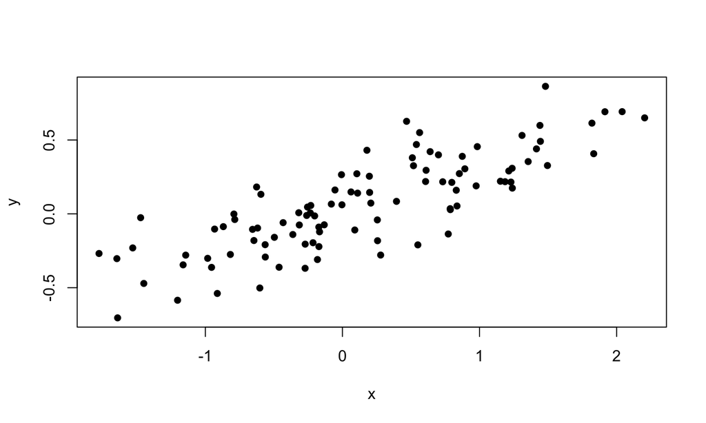

## Packages

One of the most important features of R is that it is has a vast ecosystem of user-contributed packages, which extend the base functionality of R.

Packages can be installed from the command line `install.packages('ggplot2')` or by using the graphical package manager in Rstudio in the Packages tab.

Each time you want to use functions from a package, you must make the package available with the `library()` function.

## Data Input

Getting data into R can be very frustrating for new users.

This is because we tend to be sloppy when collecting data in a spreadsheet.

R has rigid expectations.

- each column of a text file should contain a single type of data (text, numeric, factor)
- Each row should hold the observations for each column for a single individual
- That's it. Period. No extra rows that are just for formatting and don't contain data observations.

## Data Input

The primary function for reading data into R is the `read.table()` function. There are a few important arguments.

- `file` = The full path to the file as a text string. (Use the forward slash `/`, even on Windows.) You can also read from a remote URL (i.e. from the web).
- `sep` = the character that separates columns in your text file. The default is `" "`, which kind of sucks because most of our files will be separated by either `\t` or `,`.
- `header` = Whether or not there is a header row in your text file. Defaults to `FALSE`, but usually we need it to be `TRUE`.

## Challenge

Read in the file called "femur_lengths.txt" directly from the following URL

http://uncg.rstats.ninja/datasets/femur_lengths.txt

Save to an object called `femora`.

Use the `str()` function to examine the data type of each column. You can also do the same thing in R Studio in the Environment tab.

Use the `mean()` function to calculate the mean of all the femur lengths.

## Data Output

Usually, I would recommend **not** writing out modified data frames to text files.

It is far better to have a single input file, and to do all necessary manipulations in your saved R script file.

But, if you need to write data, do it with `write.table()`

- `x` = The name of the data frame to be saved.
- `file` = Path to the output file. You can't use `file.choose()` though.
- `quote` = Do you want quotation marks around strings? Defaults to `TRUE`
- `sep` = Same as for `read.table()`
- `row.names` = Do you want row names? Defaults to `TRUE`, but usually you will set to `FALSE`

## Challenge

Add a new column of log transformed lengths to the `femora` dataframe and then write out the new file to the Desktop.